# Practical: binomial regression

Physalia workshop on GLMs

Bert van der Veen

# Background

Now that we have a solid background in frequentist statistics, and linear regression in particular, we can move on to Generalised Linear Models. GLMs come to the rescue when the assumptions of linear regression are invalid, in particular the linearity, normality, and homoscedasticity assumptions.

In GLMs, the variance depends on the mean, and variance functions are usually non-linear. The mean is also non-linearly related to the data, and there is no explicit error term $\epsilon$. So, things work a little different in GLMs, but the specification in R is surprisingly similar to a linear regression!

In this practical, we will use binomial regression. Binomial regression is usually referred to as logistic, or probit, regression; the exact terminology depends on the link function that is used. By default, R assumed a logit link function. For starters, let’s simulate an example again, this time using the `rbinom` function and the `plogis` functions. We are familiar with `rbinom` from the first presentation of the workshop. The `plogis` function helps us translate from the link scale (which is where we simulate the model) $boldsymbol{\eta}$ to the response scale:

```r
x1 <- rnorm(35)
x2 <- rnorm(35)
(eta <- -2+2*x1+3.4*x2)
```

```
##  [1]  -5.22076072   2.31666158  -3.99568746   3.97432728  -4.56192693
##  [6]  -5.72797986  -8.58149497   1.07412354   0.41262802  -6.83395483
## [11]  -4.06751900   2.28425166 -11.54650439  -0.95802069  -0.29748234
## [16]   0.04796137   5.16144971  -0.91708203  -4.99023901   2.00102774
## [21]   0.67727252   2.28952896  -2.80573918  -3.74895160  -0.16752411
## [26]   5.19694904  -6.37798155   0.86791576  -3.00792340  -8.08532240
## [31]   0.27647078  -8.48967008  -4.49466660  -0.77806004   3.56248615
```

```r
(p <- plogis(eta))
```

```
##  [1] 5.374179e-03 9.102476e-01 1.806254e-02 9.815547e-01 1.033401e-02
##  [6] 3.243092e-03 1.875092e-04 7.453803e-01 6.017179e-01 1.075434e-03
## [11] 1.683166e-02 9.075643e-01 9.669692e-06 2.772747e-01 4.261731e-01
## [16] 5.119880e-01 9.942993e-01 2.855528e-01 6.758056e-03 8.809049e-01
## [21] 6.631297e-01 9.080061e-01 5.701483e-02 2.300092e-02 4.582166e-01
## [26] 9.944970e-01 1.695668e-03 7.043118e-01 4.706920e-02 3.079324e-04
## [31] 5.686808e-01 2.055388e-04 1.104505e-02 3.147381e-01 9.724143e-01
```

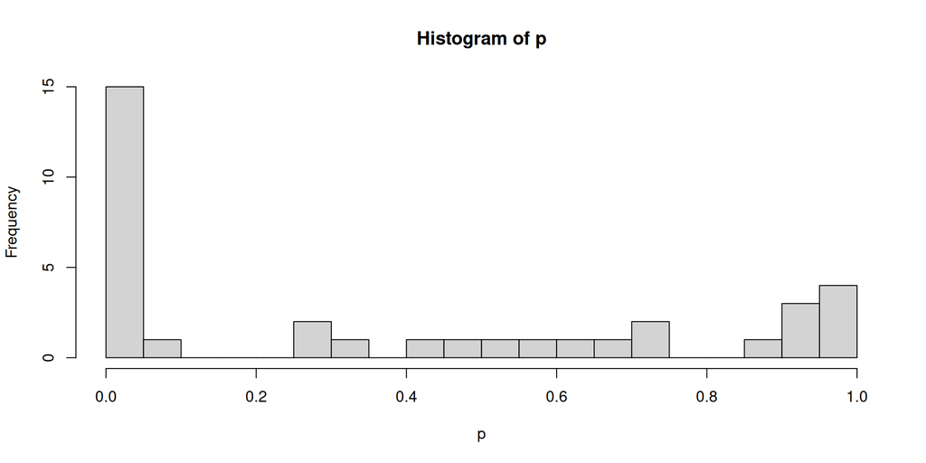

```r
hist(p, breaks = 20)
```

```r
(y <- rbinom(35, 1, p))
```

```
##  [1] 0 0 0 1 0 0 0 1 1 0 0 1 0 0 0 0 1 0 0 0 0 1 0 0 1 1 0 1 0 0 0 0 0 1 1
```

In the first lecture, $p$ was the same for all observations. Now, as in a GLM, $p$ is observation-specific. Because $p$ was different per observation, a-priori guessing the number of 1s and 0s in the data is much more challenging. Because the `size` argument was set to 1, we only simulates 1s and 0s.

We can plot the simulated data $\textbf{y}$ with the `hist` function, but a combination of `plot` and `table` makes for a nicer plot:

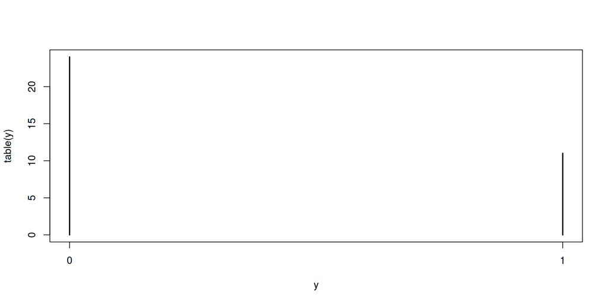

```r
plot(table(y))
```

For pedagogical purposes, we will analyse this data with a linear regression and have a look at the residuals:

```r
(reg1 <- glm(y ~ x1 + x2, family = "gaussian"))
```

```
##
## Call:  glm(formula = y ~ x1 + x2, family = "gaussian")
##
## Coefficients:
## (Intercept)           x1           x2
##      0.2813       0.2401       0.2142
##
## Degrees of Freedom: 34 Total (i.e. Null);  32 Residual
## Null Deviance:       7.543
## Residual Deviance: 3.991     AIC: 31.33
```

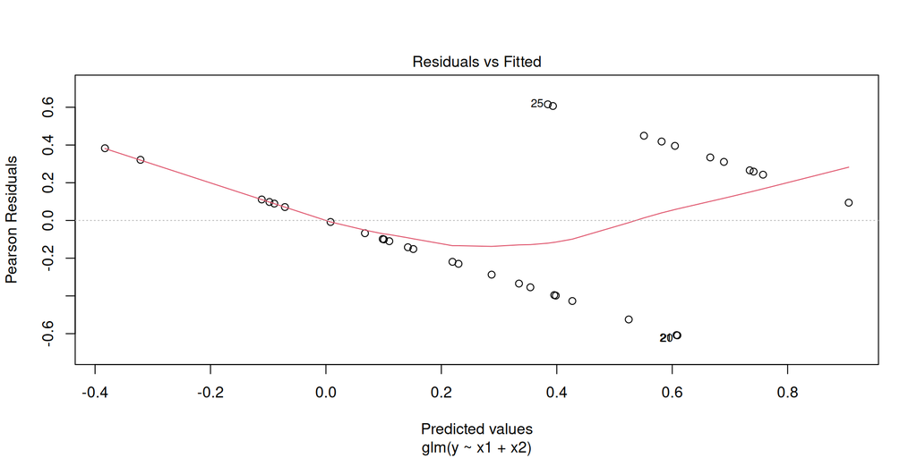

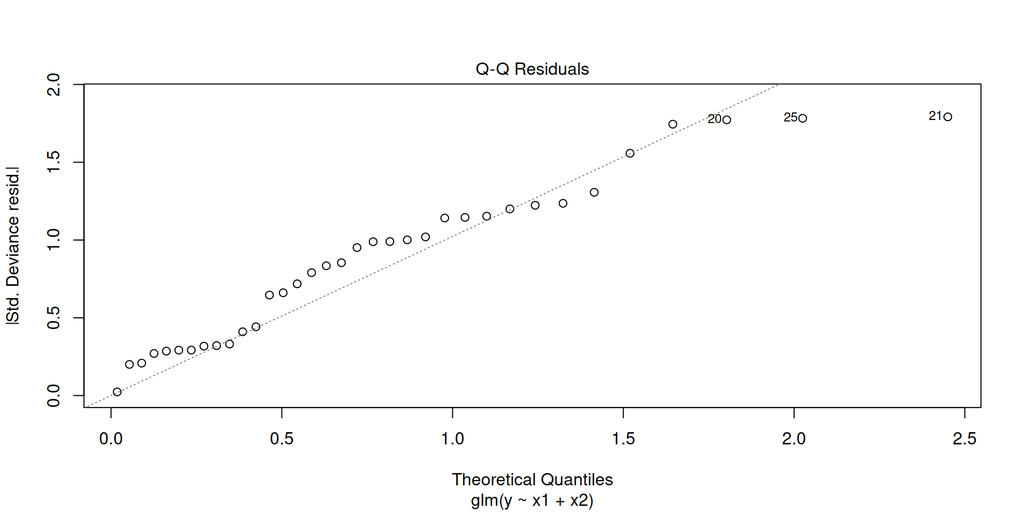

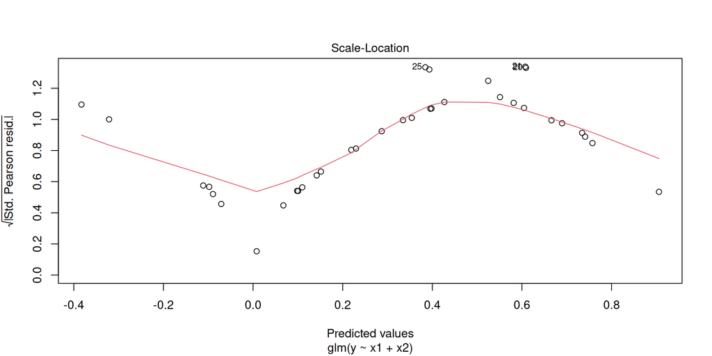

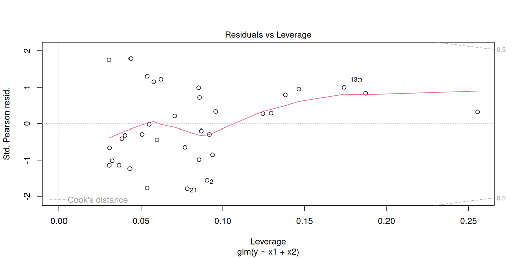

```r
plot(reg1)
```

“Gaussian” is synonymous to “normal” in terms of response distribution; this is how a linear model is fitted using the `glm` function. The true parameters we simulated for were $\alpha = -2$, $\beta_1 = 2$ and $\beta_2 = 3.4$. Clearly, none of these estimates comes close. We cannot transform our way out of this issue. The residual plots look terrible, because our data is discrete and only takes 0 or 1. We need to fit a GLM!

```r
(reg2 <- glm(y ~ x1 + x2, family = "binomial"))
```

```
##
## Call:  glm(formula = y ~ x1 + x2, family = "binomial")
##
## Coefficients:
## (Intercept)           x1           x2
##      -2.653        2.617        2.483
##
## Degrees of Freedom: 34 Total (i.e. Null);  32 Residual
## Null Deviance:       43.57
## Residual Deviance: 19.46     AIC: 25.46
```

The parameter estimate are much closer to the ones we simulated from. They are still a little different, but this is due to the “small” sample. They cannot be directly interpreted in terms of the response scale, i.e., the scale the data is on, but they can be interpreted in terms of changes in the log-odds. Generally speaking, a negative coefficient means a negative relationship between $p_i$ and the predictor, and positive the opposite.

The `marginaleffects` can help us to interpret effects on the response scale; in particular the `plot_slopes` function is help to assess how the probability of success $p_i$ changes with a covariate, which provides similar interpretation to that in a linear model:

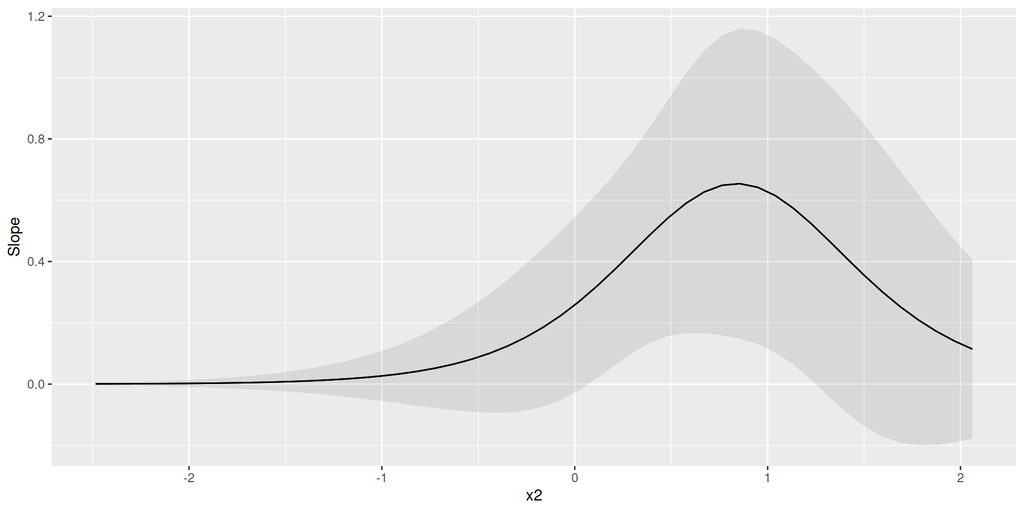

```r
library(marginaleffects)
plot_slopes(reg2, variables = "x1", condition = "x2")
```

However, because we now have a non-linear model, this change is not the same everywhere. We can still try to summarize it with a single value:

```r
avg_slopes(reg2)
```

```
##
##  Term Estimate Std. Error    z Pr(>|z|)    S 2.5 % 97.5 %
##    x1    0.227     0.0347 6.53   <0.001 33.9 0.159  0.295
##    x2    0.215     0.0496 4.33   <0.001 16.0 0.118  0.312
##
## Type:  response
## Columns: term, estimate, std.error, statistic, p.value, s.value, conf.low, conf.high
```

but this is not particularly helpful. The `slopes` function provides the same information but per observation. The `marginaleffects` package can also help make pairwise comparisons when there is a categorical predictor in the model with the `comparisons` function.

Finally, solely for the purpose of demonstration, we can change the link function as follows:

```r
(reg3 <- glm(y ~ x1 + x2, family = binomial(link=probit)))
```

```
##
## Call:  glm(formula = y ~ x1 + x2, family = binomial(link = probit))
##
## Coefficients:
## (Intercept)           x1           x2
##      -1.556        1.558        1.475
##
## Degrees of Freedom: 34 Total (i.e. Null);  32 Residual
## Null Deviance:       43.57
## Residual Deviance: 19.13     AIC: 25.13
```

Just as in linear models, we use very similar functions to extract coefficients, calculate confidence intervals, and so on:

- `plot`: draws all kinds of plots (controlled by `type`), but usually a scatterplot
- `glm`: fits a generalized linear regression to data
- `summary`: provides a summary table for a (linear) model
- `confint`: calculates (estimated) confidence intervals for the parameters of a model
- `predict`: calculates the predicted values from a regression, potentially for new $X$
- `pairs`: construct a panel of plots for a dataset
- `relevel`: changes the reference category for a factor

If you do not remember what these functions do, or what arguments they take, you can look it up by typing `?functionName` in the console. That will show you the help page of the function, which hopefully clarifies things. If it does not, try a search engine to find online resources, or ask someone. Almost always your question has been asked (and answered) by someone else before. Some hints are given with questions **in bold**.

# Datasets

We will use the same datasets as in the last practical. You can find the datasets in the “data” folder of the github repository.

1. [nickel.expand](https://raw.githubusercontent.com/BertvanderVeen/GLM-workshop/refs/heads/main/data/nickel.expand.csv): Lung cancer due to nickel exposure in South Wales [Breslow and Day (1987)](https://pubmed.ncbi.nlm.nih.gov/3329634/). You can use lung cancer and nasal cancer rates as response variable
2. [dmn](https://raw.githubusercontent.com/BertvanderVeen/GLM-workshop/refs/heads/main/data/dmn.csv): de novo mutations in children [Halldorsson et al. (2019)](https://www.science.org/doi/10.1126/science.aau1043), see also [this page](https://mccoy-lab.github.io/hgv_modules/setup.html). You can use de novo mutations of father and mother as a response variable
3. Baseball: attendance to baseball games [Cochran 2002](https://jse.amstat.org/v10n2/datasets.cochran.html)
5. Lizards: Lizard counts, used in the presentation, includes a count of two lizard species and multiple categorical covariates [(Schoener 1970)](https://esajournals.onlinelibrary.wiley.com/doi/10.2307/1935376)
6. wells: Water quality of contaminated wells (y vs n) in New York with variables of surrounding land use, sewer usage, and nitrate and chloride concentration [(Eckhard et al. 1989)](https://pubs.usgs.gov/publication/wri864142)

# Part 1 (we only have one part)

Here is what I want you to do:

1. Choose your dataset and fit a binomial regression.
2. Study the parameter estimates and their uncertainty. What conclusion can you draw?
3. How much do the parameter estimates and their uncertainty change, using a probit link function, compared to the default logit?
4. Can you predict the probability of success for a particular subset of conditions (e.g., wells with used sewers, high nitrate, low chloride)? *Hint: use the predict function and its ‘newdata’ and ‘type’ arguments*
5. Plot the binomial regression against one of the predictor variables.
6. Plot the residuals of the model, how do they look? Can you discern any assumption violations?